# Machine Learning Final Project

Authors

Affiliation

Adam Lodrik

University of Lausanne

Favre Stefan

Macaraeg Jeff

Published

May 14, 2024

Abstract

# 1 Introduction

• The context and background: course, company name, business context.

During our 1st master year as students in Management - orientation Business Analytics, we have had the opportunity to attend some lectures of Machine Learning for Business Analytics. In content of this class, we have seen multiple machine learning techniques for business context, mainly covering supervised (regressions, trees, support vector machine, neural networks) and unsupervised methods (clustering, PCA, FAMD, Auto-Encoder) but also other topics such as data splitting, ensemble methods and metrics.

• Aim of the investigation: major terms should be defined, the question of research (more generally the issue), why it is of interest and relevant in that context.

In the context of this class, our group have had the opportunity to work on an applied project. From scratch, we had to look for some potential dataset for using on real cases what we have learned in class. Thus, we had found an interesting dataset concerning vehicule MPG, range, engine stats and more, for more than 100 brands. The goal of our research was to predict the make (i.e. the brand) of the car according to its characteristics (consumption, range, fuel type, … ) thanks to a model that we would have trained (using RF, ANN or Trees). As some cars could have several identical characteristics, but could differentiate on various other ones, we thought that it would be pertinent to have a model that was able to predict a car brand, from its features.

• Description of the data and the general material provided and how it was made available (and/or collected, if it is relevant). Only in broad terms however, the data will be further described in a following section. Typically, the origin/source of the data (the company, webpage, etc.), the type of files (Excel files, etc.), and what it contains in broad terms (e.g. “a file containing weekly sales with the factors of interest including in particular the promotion characteristics”).

The csv dataset has been found on data.world, a data catalog platform that gather various open access datasets online. The file contains more than 45’000 rows and 26 columns, each colomn concerning one feature (such as the year of the brand, the model, the consumption per barrel, the highway mpg per fuel type and so on).

• The method that is used, in broad terms, no details needed at this point. E.g. “Model based machine learning will help us quantifying the important factors on the sales”.

Among these columns, we have had to find a machine learning model that could help us quantify the importance of the features in predicting the make of the car. Various models will be tried for both supervised and unsupervised learnings.

# 2 Data description

### 2.0.1 The features or variables: type, units,…

| Variable Name | Explanation |
| --- | --- |
| ID | Number corresponding to the precise combination of the features of the model |
| Model Year | Year of the model of the car |
| Make | The brand of the car |
| Model | The model of the car |
| Estimated Annual Petroleum Consumption (Barrels) | Consumption in Petroleum Barrels |
| Fuel Type 1 | First fuel energy source, only source if not an hybrid car |
| City MPG (Fuel Type 1) |  |
| Highway MPG (Fuel Type 1) |  |
| Combined MPG (Fuel Type 1) |  |
| Fuel Type 2 | Second energy source if hybrid car |
| City MPG (Fuel Type 2) |  |
| Highway MPG (Fuel Type 2) |  |
| Combined MPG (Fuel Type 2) |  |
| Engine Cylinders | From 2 to 16 cylinders |
| Engine Displacement | Measure of the cylinder volume swept by all of the pistons of a piston engine, excluding the combustion chambers |
| Drive | Description of the car, e.g. Turbo, Stop-Start, ... |
| Engine Description | Manual/Automatic transmission, with number of gears and/or model of transmission |
| Transmission | e.g. Minivan, Trucks, Midsize,.... |
| Vehicle Class |  |
| Time to Charge EV (hours at 120v) |  |
| Time to Charge EV (hours at 240v) |  |
| Range (for EV) |  |
| City Range (for EV - Fuel Type 1) |  |
| City Range (for EV - Fuel Type 2) |  |
| Hwy Range (for EV - Fuel Type 1) |  |
| Hwy Range (for EV - Fuel Type 2) |  |

## 2.1 The instances: customers, company, products, subjects, etc.

In a basic instance, each row is concerning one car. We can find in order the ID of the car corresponding to a precise feature observation, then the features as seen in the table before.

## 2.2 Missing data pattern: if there are missing data, if they are specific to some features, etc.

## 2.3 Any modification to the initial data: aggregation, imputation in replacement of missing data, recoding of levels, etc.

## 2.4 If only a subset was used, it should be mentioned and explained; e.g. inclusion criteria. Note that if inclusion criteria do not exist and the inclusion was an arbitrary choice, it should be stated as such. One should not try to invent unreal justifications.

*EDA:*

**Columns description**

To begin with our EDA, let’s have a look at our dataset and in particular the characteristics of the columns.

```r
#to get a detailed summary
skim(data)
```

Data summary

| Name | data |
| --- | --- |
| Number of rows | 45896 |
| Number of columns | 26 |
| _______________________ |  |
| Column type frequency: |  |
| character | 8 |
| numeric | 18 |
| ________________________ |  |
| Group variables | None |

**Variable type: character**

| skim_variable | n_missing | complete_rate | min | max | empty | n_unique | whitespace |
| --- | --- | --- | --- | --- | --- | --- | --- |
| Make | 0 | 1.00 | 3 | 34 | 0 | 141 | 0 |
| Model | 0 | 1.00 | 1 | 47 | 0 | 4762 | 0 |
| Fuel Type 1 | 0 | 1.00 | 6 | 17 | 0 | 6 | 0 |
| Fuel Type 2 | 44059 | 0.04 | 3 | 11 | 0 | 4 | 0 |
| Drive | 1186 | 0.97 | 13 | 26 | 0 | 7 | 0 |
| Engine Description | 17031 | 0.63 | 1 | 46 | 0 | 589 | 0 |
| Transmission | 11 | 1.00 | 12 | 32 | 0 | 40 | 0 |
| Vehicle Class | 0 | 1.00 | 4 | 34 | 0 | 34 | 0 |

**Variable type: numeric**

| skim_variable | n_missing | complete_rate | mean | sd | p0 | p25 | p50 | p75 | p100 | hist |
| --- | --- | --- | --- | --- | --- | --- | --- | --- | --- | --- |
| ID | 0 | 1.00 | 23102.11 | 13403.10 | 1.00 | 11474.75 | 23090.50 | 34751.25 | 46332.00 | ▇▇▇▇▇ |
| Model Year | 0 | 1.00 | 2003.61 | 12.19 | 1984.00 | 1992.00 | 2005.00 | 2015.00 | 2023.00 | ▇▆▆▇▇ |
| Estimated Annual Petrolum Consumption (Barrels) | 0 | 1.00 | 15.33 | 4.34 | 0.05 | 12.94 | 14.88 | 17.50 | 42.50 | ▁▇▃▁▁ |
| City MPG (Fuel Type 1) | 0 | 1.00 | 19.11 | 10.31 | 6.00 | 15.00 | 17.00 | 21.00 | 150.00 | ▇▁▁▁▁ |
| Highway MPG (Fuel Type 1) | 0 | 1.00 | 25.16 | 9.40 | 9.00 | 20.00 | 24.00 | 28.00 | 140.00 | ▇▁▁▁▁ |
| Combined MPG (Fuel Type 1) | 0 | 1.00 | 21.33 | 9.78 | 7.00 | 17.00 | 20.00 | 23.00 | 142.00 | ▇▁▁▁▁ |
| City MPG (Fuel Type 2) | 0 | 1.00 | 0.85 | 6.47 | 0.00 | 0.00 | 0.00 | 0.00 | 145.00 | ▇▁▁▁▁ |
| Highway MPG (Fuel Type 2) | 0 | 1.00 | 1.00 | 6.55 | 0.00 | 0.00 | 0.00 | 0.00 | 121.00 | ▇▁▁▁▁ |
| Combined MPG (Fuel Type 2) | 0 | 1.00 | 0.90 | 6.43 | 0.00 | 0.00 | 0.00 | 0.00 | 133.00 | ▇▁▁▁▁ |
| Engine Cylinders | 487 | 0.99 | 5.71 | 1.77 | 2.00 | 4.00 | 6.00 | 6.00 | 16.00 | ▇▇▅▁▁ |
| Engine Displacement | 485 | 0.99 | 3.28 | 1.36 | 0.00 | 2.20 | 3.00 | 4.20 | 8.40 | ▁▇▅▂▁ |
| Time to Charge EV (hours at 120v) | 0 | 1.00 | 0.00 | 0.00 | 0.00 | 0.00 | 0.00 | 0.00 | 0.00 | ▁▁▇▁▁ |
| Time to Charge EV (hours at 240v) | 0 | 1.00 | 0.11 | 1.01 | 0.00 | 0.00 | 0.00 | 0.00 | 15.30 | ▇▁▁▁▁ |
| Range (for EV) | 0 | 1.00 | 2.36 | 24.97 | 0.00 | 0.00 | 0.00 | 0.00 | 520.00 | ▇▁▁▁▁ |
| City Range (for EV - Fuel Type 1) | 0 | 1.00 | 1.62 | 20.89 | 0.00 | 0.00 | 0.00 | 0.00 | 520.80 | ▇▁▁▁▁ |
| City Range (for EV - Fuel Type 2) | 0 | 1.00 | 0.17 | 2.73 | 0.00 | 0.00 | 0.00 | 0.00 | 135.28 | ▇▁▁▁▁ |
| Hwy Range (for EV - Fuel Type 1) | 0 | 1.00 | 1.51 | 19.70 | 0.00 | 0.00 | 0.00 | 0.00 | 520.50 | ▇▁▁▁▁ |
| Hwy Range (for EV - Fuel Type 2) | 0 | 1.00 | 0.16 | 2.46 | 0.00 | 0.00 | 0.00 | 0.00 | 114.76 | ▇▁▁▁▁ |

The dataset that we are working with contains approx. 46’000 rows and 26 columns. We can see that most of our features are concerning the consumption of the cars. In addition, we notice that some variables contain a lot of missing and that the variable “Time.to.Charge.EV..hours.at.120v.” is only containing 0s. We will be handle these in the section “data cleaning”.

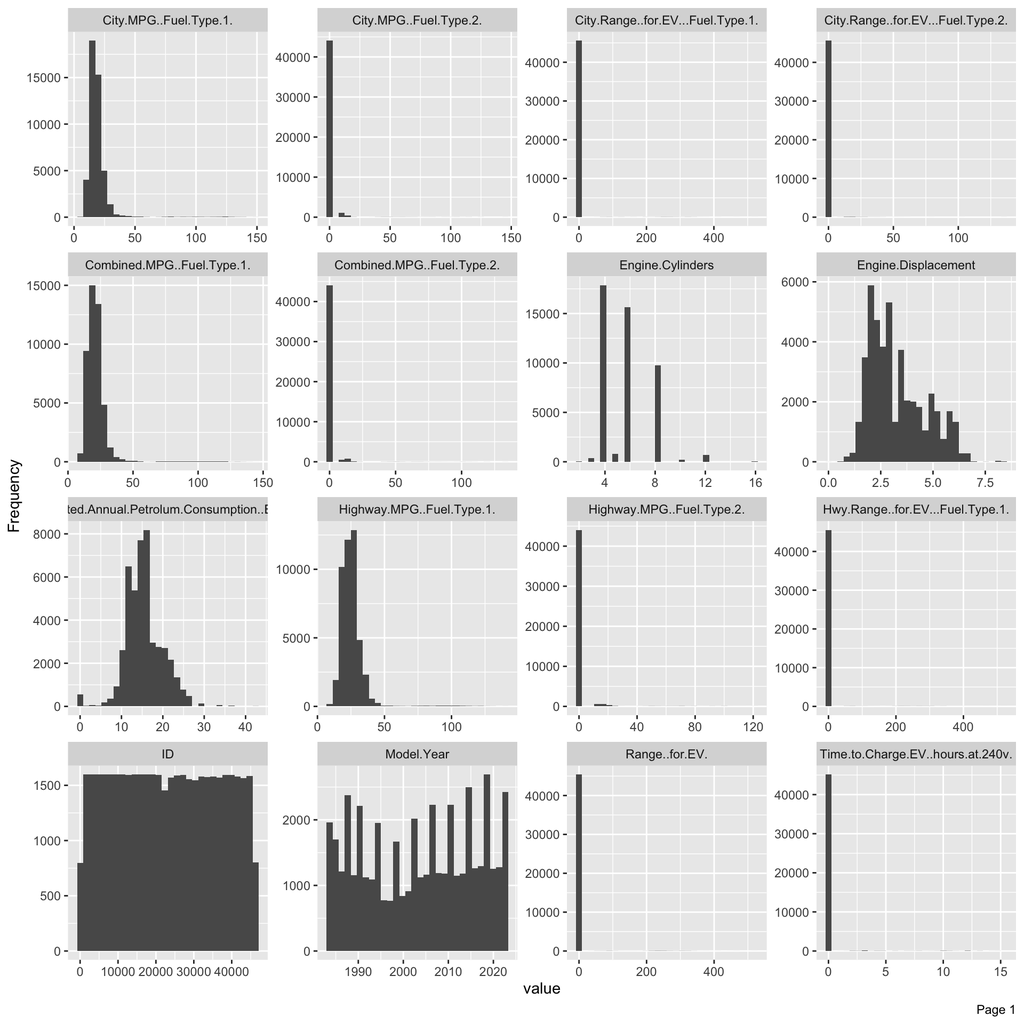

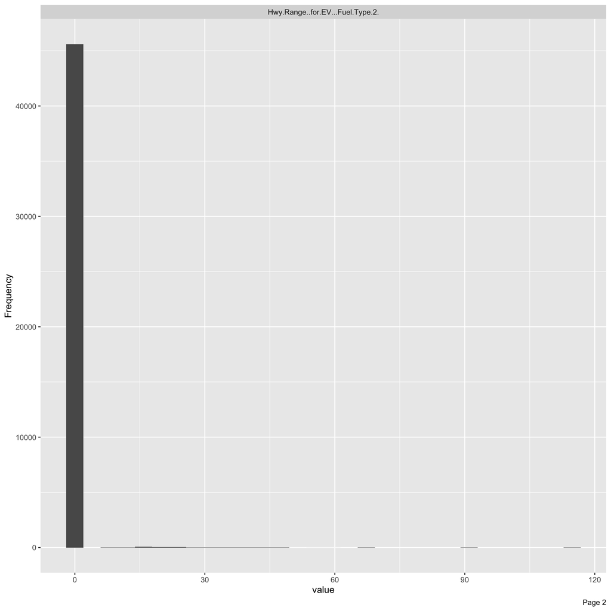

```r
#  melt.data <- melt(data)
#
#  ggplot(data = melt.data, aes(x = value)) +
# stat_density() +
# facet_wrap(~variable, scales = "free")

plot_histogram(data)# Time.to.Charge.EV..hours.at.120v. not appearing because all observations = 0
```

```r
#tentative boxplots

# data_long <- data %>%
#   select_if(is.numeric) %>%
#   pivot_longer(cols = c("ID",
#   "Model.Year",
#  "Estimated.Annual.Petrolum.Consumption..Barrels.",
#  "City.MPG..Fuel.Type.1.",
#  "Highway.MPG..Fuel.Type.1." ,
#  "Combined.MPG..Fuel.Type.1.",
#  "City.MPG..Fuel.Type.2." ,
#  "Highway.MPG..Fuel.Type.2.",
#  "Combined.MPG..Fuel.Type.2."   ,
# "Time.to.Charge.EV..hours.at.120v." ,
#  "Time.to.Charge.EV..hours.at.240v." ,
# "Range..for.EV.",
# "City.Range..for.EV...Fuel.Type.1.",
# "City.Range..for.EV...Fuel.Type.2.",
# "Hwy.Range..for.EV...Fuel.Type.1." ,
# "Hwy.Range..for.EV...Fuel.Type.2." ), names_to = "variable", values_to = "value")
#
# ggplot(data_long, aes(x = variable, y = value, fill = variable)) +
#   geom_boxplot() +
#   facet_wrap(~ variable, scales = "free_y") +  # Each variable gets its own y-axis
#   theme_minimal() +
#   labs(title = "Boxplots of Variables with Different Scales", x = "", y = "Value")
```

```r
#Now
# plot_correlation(data) #drop time charge EV 120V
# create_report(data)
#nb cars per brand
```

```r
#Number of occurences/model per make
nb_model_per_make <- data %>%
  group_by(Make, Model) %>%
  summarise(Number = n(), .groups = 'drop') %>%
  group_by(Make) %>%
  summarise(Models_Per_Make = n(), .groups = 'drop') %>%
  arrange(desc(Models_Per_Make))

#table
datatable(nb_model_per_make,
          rownames = FALSE,
          options = list(pageLength = 10,
                         class = "hover",
                         searchHighlight = TRUE))
```

| Make | Models_Per_Make |
| --- | --- |
| Mercedes-Benz | 420 |
| BMW | 416 |
| Chevrolet | 268 |
| Ford | 261 |
| Porsche | 191 |
| GMC | 169 |
| Audi | 159 |
| Toyota | 151 |
| Nissan | 133 |
| Dodge | 121 |

[output cut: 131 more lines]

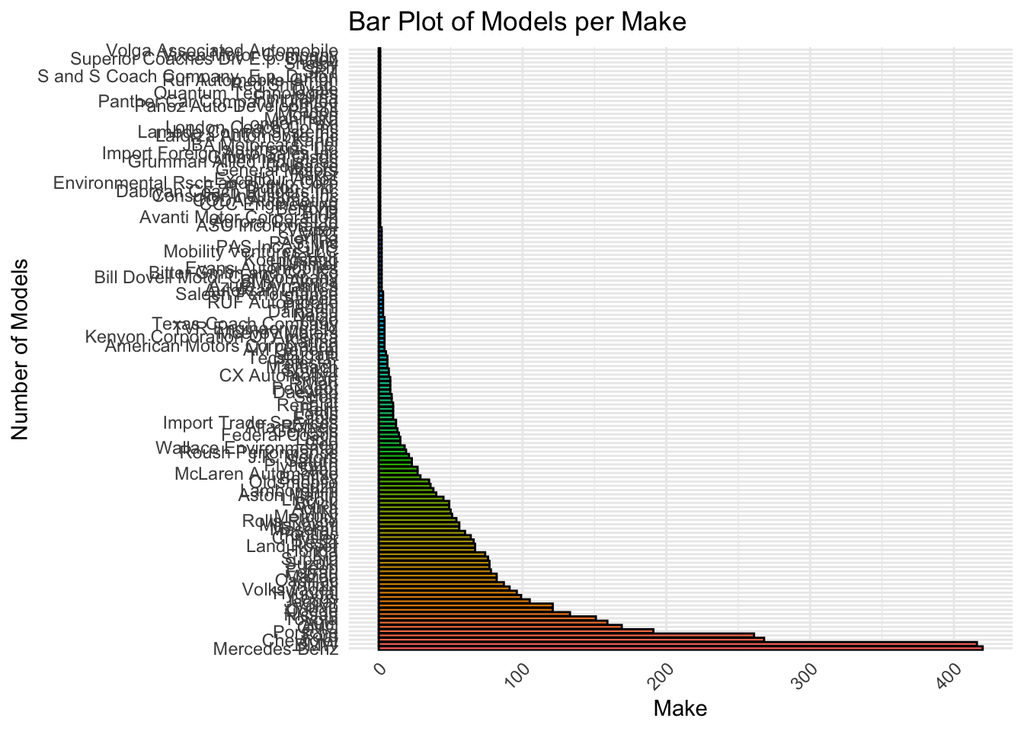

```r
# Reordering the Make variable within the plotting code to make it ordered by Models_Per_Make descending
nb_model_per_make$Make <- factor(nb_model_per_make$Make, levels = nb_model_per_make$Make[order(-nb_model_per_make$Models_Per_Make)])

# Bar Plot
ggplot(nb_model_per_make, aes(x = Models_Per_Make, y = Make, fill = Make)) +
  geom_bar(stat = "identity", color = "black", show.legend = FALSE) +
  labs(title = "Bar Plot of Models per Make",
       x = "Make",
       y = "Number of Models") +
  theme_minimal() +
  theme(axis.text.x = element_text(angle = 45, hjust = 1))  # Rotate x labels for better visibility
```

```r
library(corrplot)
library(reshape2)
#select only numerical columns, drop Time.to.Charge.EV..hours.at.120v. because NAs
data_corrplot <- data %>%
  select_if(is.numeric)


#correlation transformation for plot
cor_matrix <- cor(data_corrplot, use = "complete.obs")
print(cor_matrix)
```

```
                                                          ID   Model Year
ID                                               1.000000000  0.898172038
Model Year                                       0.898172038  1.000000000
Estimated Annual Petrolum Consumption (Barrels) -0.266893652 -0.276815795
City MPG (Fuel Type 1)                           0.241377134  0.228012823
Highway MPG (Fuel Type 1)                        0.283084314  0.291126991
Combined MPG (Fuel Type 1)                       0.261835243  0.256301039
City MPG (Fuel Type 2)                           0.134630658  0.134178928
Highway MPG (Fuel Type 2)                        0.146379198  0.147794175
Combined MPG (Fuel Type 2)                       0.140054478  0.140327837
Engine Cylinders                                 0.033692800  0.050183765
Engine Displacement                             -0.003199825  0.003489418
Time to Charge EV (hours at 120v)                         NA           NA
Time to Charge EV (hours at 240v)                0.105358751  0.099465867
Range (for EV)                                            NA           NA
City Range (for EV - Fuel Type 1)                         NA           NA
City Range (for EV - Fuel Type 2)                0.087660644  0.082763271
Hwy Range (for EV - Fuel Type 1)                          NA           NA
Hwy Range (for EV - Fuel Type 2)                 0.091333071  0.086200984
                                                Estimated Annual Petrolum Consumption (Barrels)
ID                                                                                   -0.2668937
Model Year                                                                           -0.2768158
Estimated Annual Petrolum Consumption (Barrels)                                       1.0000000
City MPG (Fuel Type 1)                                                               -0.8653379
Highway MPG (Fuel Type 1)                                                            -0.9035610
Combined MPG (Fuel Type 1)                                                           -0.9001868
City MPG (Fuel Type 2)                                                               -0.1689445
Highway MPG (Fuel Type 2)                                                            -0.1539511
Combined MPG (Fuel Type 2)                                                           -0.1637478
Engine Cylinders                                                                      0.7331933
Engine Displacement                                                                   0.7837093
Time to Charge EV (hours at 120v)                                                            NA
Time to Charge EV (hours at 240v)                                                    -0.1859223
Range (for EV)                                                                               NA
City Range (for EV - Fuel Type 1)                                                            NA
City Range (for EV - Fuel Type 2)                                                    -0.1727049
Hwy Range (for EV - Fuel Type 1)                                                             NA
Hwy Range (for EV - Fuel Type 2)                                                     -0.1766306
                                                City MPG (Fuel Type 1)
ID                                                           0.2413771
```

[output cut: 268 more lines]

```
City MPG (Fuel Type 1)                                                0.15108834
Highway MPG (Fuel Type 1)                                             0.07924589
Combined MPG (Fuel Type 1)                                            0.12426275
City MPG (Fuel Type 2)                                                0.81001967
Highway MPG (Fuel Type 2)                                             0.75599220
Combined MPG (Fuel Type 2)                                            0.79135465
Engine Cylinders                                                     -0.05749263
Engine Displacement                                                  -0.06348857
Time to Charge EV (hours at 120v)                                             NA
Time to Charge EV (hours at 240v)                                     0.90893793
Range (for EV)                                                                NA
City Range (for EV - Fuel Type 1)                                             NA
City Range (for EV - Fuel Type 2)                                     0.99601860
Hwy Range (for EV - Fuel Type 1)                                              NA
Hwy Range (for EV - Fuel Type 2)                                      1.00000000
```

```r
kable(cor_matrix)
```

|  | ID | Model Year | Estimated Annual Petrolum Consumption (Barrels) | City MPG (Fuel Type 1) | Highway MPG (Fuel Type 1) | Combined MPG (Fuel Type 1) | City MPG (Fuel Type 2) | Highway MPG (Fuel Type 2) | Combined MPG (Fuel Type 2) | Engine Cylinders | Engine Displacement | Time to Charge EV (hours at 120v) | Time to Charge EV (hours at 240v) | Range (for EV) | City Range (for EV - Fuel Type 1) | City Range (for EV - Fuel Type 2) | Hwy Range (for EV - Fuel Type 1) | Hwy Range (for EV - Fuel Type 2) |
| --- | --- | --- | --- | --- | --- | --- | --- | --- | --- | --- | --- | --- | --- | --- | --- | --- | --- | --- |
| ID | 1.0000000 | 0.8981720 | -0.2668937 | 0.2413771 | 0.2830843 | 0.2618352 | 0.1346307 | 0.1463792 | 0.1400545 | 0.0336928 | -0.0031998 | NA | 0.1053588 | NA | NA | 0.0876606 | NA | 0.0913331 |
| Model Year | 0.8981720 | 1.0000000 | -0.2768158 | 0.2280128 | 0.2911270 | 0.2563010 | 0.1341789 | 0.1477942 | 0.1403278 | 0.0501838 | 0.0034894 | NA | 0.0994659 | NA | NA | 0.0827633 | NA | 0.0862010 |
| Estimated Annual Petrolum Consumption (Barrels) | -0.2668937 | -0.2768158 | 1.0000000 | -0.8653379 | -0.9035610 | -0.9001868 | -0.1689445 | -0.1539511 | -0.1637478 | 0.7331933 | 0.7837093 | NA | -0.1859223 | NA | NA | -0.1727049 | NA | -0.1766306 |
| City MPG (Fuel Type 1) | 0.2413771 | 0.2280128 | -0.8653379 | 1.0000000 | 0.9207665 | 0.9857637 | 0.1671384 | 0.1420879 | 0.1574358 | -0.6771928 | -0.7115445 | NA | 0.1414919 | NA | NA | 0.1530046 | NA | 0.1510883 |
| Highway MPG (Fuel Type 1) | 0.2830843 | 0.2911270 | -0.9035610 | 0.9207665 | 1.0000000 | 0.9677170 | 0.0890395 | 0.0751494 | 0.0835921 | -0.6468990 | -0.7063142 | NA | 0.0712719 | NA | NA | 0.0801444 | NA | 0.0792459 |
| Combined MPG (Fuel Type 1) | 0.2618352 | 0.2563010 | -0.9001868 | 0.9857637 | 0.9677170 | 1.0000000 | 0.1365411 | 0.1157063 | 0.1284624 | -0.6825224 | -0.7267671 | NA | 0.1153313 | NA | NA | 0.1256720 | NA | 0.1242627 |
| City MPG (Fuel Type 2) | 0.1346307 | 0.1341789 | -0.1689445 | 0.1671384 | 0.0890395 | 0.1365411 | 1.0000000 | 0.9832273 | 0.9970007 | -0.0231218 | -0.0248593 | NA | 0.8300337 | NA | NA | 0.7992789 | NA | 0.8100197 |
| Highway MPG (Fuel Type 2) | 0.1463792 | 0.1477942 | -0.1539511 | 0.1420879 | 0.0751494 | 0.1157063 | 0.9832273 | 1.0000000 | 0.9941925 | -0.0056200 | -0.0059665 | NA | 0.7991680 | NA | NA | 0.7391649 | NA | 0.7559922 |
| Combined MPG (Fuel Type 2) | 0.1400545 | 0.1403278 | -0.1637478 | 0.1574358 | 0.0835921 | 0.1284624 | 0.9970007 | 0.9941925 | 1.0000000 | -0.0161858 | -0.0173876 | NA | 0.8223966 | NA | NA | 0.7776109 | NA | 0.7913547 |
| Engine Cylinders | 0.0336928 | 0.0501838 | 0.7331933 | -0.6771928 | -0.6468990 | -0.6825224 | -0.0231218 | -0.0056200 | -0.0161858 | 1.0000000 | 0.9051909 | NA | -0.0496963 | NA | NA | -0.0577003 | NA | -0.0574926 |
| Engine Displacement | -0.0031998 | 0.0034894 | 0.7837093 | -0.7115445 | -0.7063142 | -0.7267671 | -0.0248593 | -0.0059665 | -0.0173876 | 0.9051909 | 1.0000000 | NA | -0.0602166 | NA | NA | -0.0629302 | NA | -0.0634886 |
| Time to Charge EV (hours at 120v) | NA | NA | NA | NA | NA | NA | NA | NA | NA | NA | NA | 1 | NA | NA | NA | NA | NA | NA |
| Time to Charge EV (hours at 240v) | 0.1053588 | 0.0994659 | -0.1859223 | 0.1414919 | 0.0712719 | 0.1153313 | 0.8300337 | 0.7991680 | 0.8223966 | -0.0496963 | -0.0602166 | NA | 1.0000000 | NA | NA | 0.8812479 | NA | 0.9089379 |
| Range (for EV) | NA | NA | NA | NA | NA | NA | NA | NA | NA | NA | NA | NA | NA | 1 | NA | NA | NA | NA |
| City Range (for EV - Fuel Type 1) | NA | NA | NA | NA | NA | NA | NA | NA | NA | NA | NA | NA | NA | NA | 1 | NA | NA | NA |
| City Range (for EV - Fuel Type 2) | 0.0876606 | 0.0827633 | -0.1727049 | 0.1530046 | 0.0801444 | 0.1256720 | 0.7992789 | 0.7391649 | 0.7776109 | -0.0577003 | -0.0629302 | NA | 0.8812479 | NA | NA | 1.0000000 | NA | 0.9960186 |
| Hwy Range (for EV - Fuel Type 1) | NA | NA | NA | NA | NA | NA | NA | NA | NA | NA | NA | NA | NA | NA | NA | NA | 1 | NA |
| Hwy Range (for EV - Fuel Type 2) | 0.0913331 | 0.0862010 | -0.1766306 | 0.1510883 | 0.0792459 | 0.1242627 | 0.8100197 | 0.7559922 | 0.7913547 | -0.0574926 | -0.0634886 | NA | 0.9089379 | NA | NA | 0.9960186 | NA | 1.0000000 |

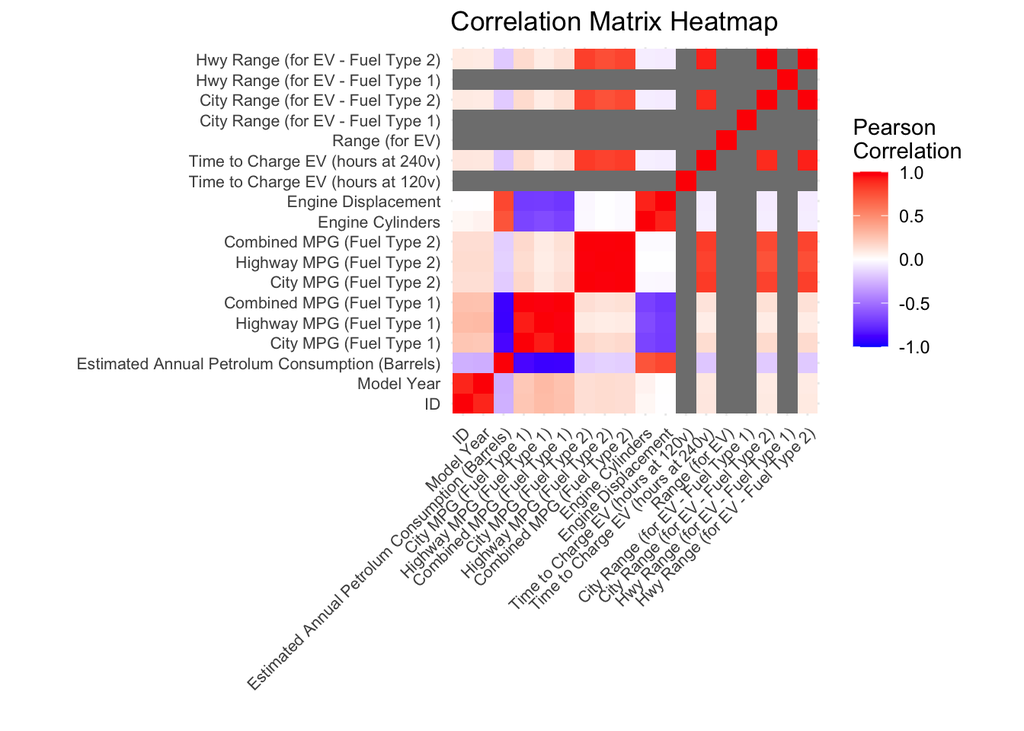

```r
cor_melted <- melt(cor_matrix)


#plot
ggplot(data = cor_melted, aes(Var1, Var2, fill = value)) +
  geom_tile() +
  scale_fill_gradient2(low = "blue", high = "red", mid = "white",
                       midpoint = 0, limit = c(-1, 1), space = "Lab",
                       name="Pearson\nCorrelation") +
  theme_minimal() +
  theme(axis.text.x = element_text(angle = 45, vjust = 1, size = 8, hjust = 1),
        axis.text.y = element_text(size = 8)) +
  coord_fixed() +
  labs(x = '', y = '', title = 'Correlation Matrix Heatmap')
```

# 3 Data cleaning

In this section we will handle the missing value of our dataset to make sure that we have a clean dataset to perform our EDA and modeling. We will first visualize the missing values in our dataset and then clean the missing values in the columns that we will use for our analysis. We will also remove some rows and columns that are not relevant for our analysis.

Let’s have a look at the entire dataset and its missing values in grey.

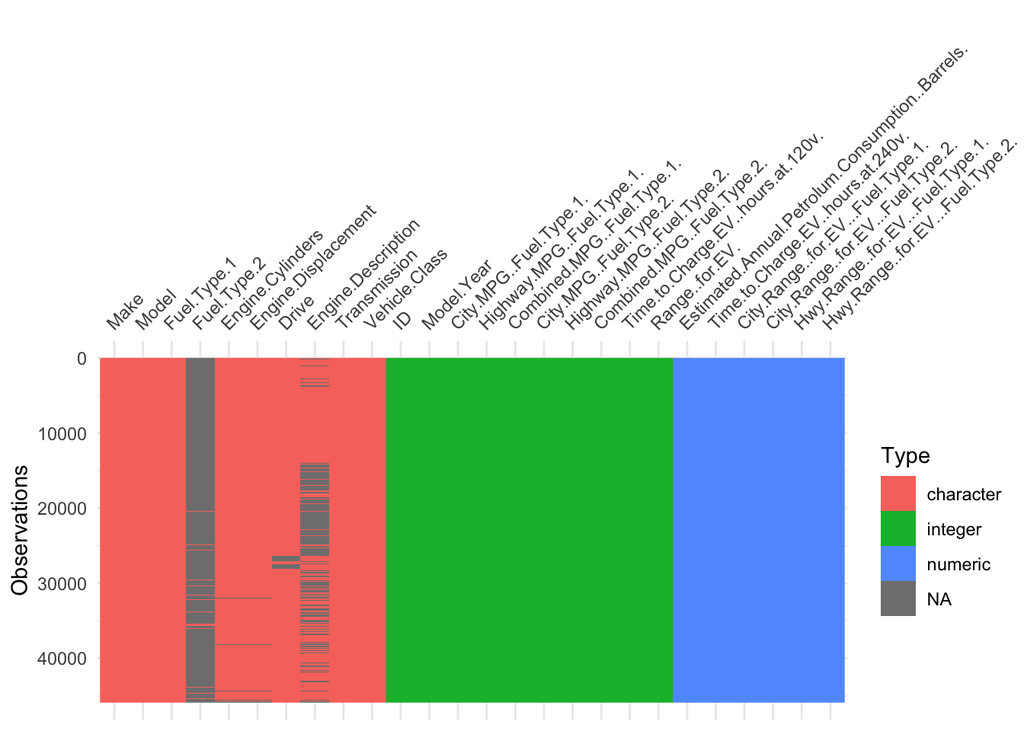

We can see that overall, we do not have many missing values in proportion with the size of our dataset. However, we can see that some columns have a lot of missing values. Let’s have a look at the columns and rows with missing values more in details.

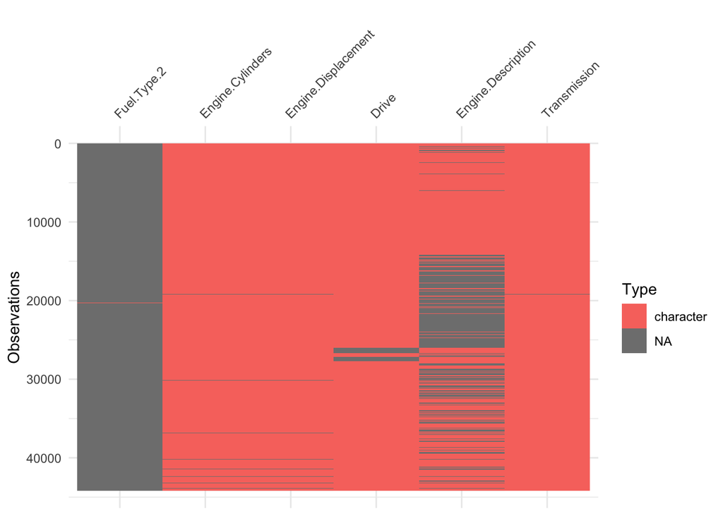

We can now more easily see the missing in our data. Below we have the detail of the pourcentage of missing values by columns.

| Column | Missing values | Prop. Missing |
| --- | --- | --- |
| Fuel.Type.2 | 44059 | 0.9599747254662716 |
| Engine.Description | 17031 | 0.3710780895938644 |
| Drive | 1186 | 0.02584103189820464 |
| Engine.Cylinders | 484 | 0.01054558131427575 |
| Engine.Displacement | 483 | 0.01052379292313056 |
| Transmission | 11 | 0.0002396723025971762 |
| ID | 0 | 0 |
| Model.Year | 0 | 0 |
| Make | 0 | 0 |
| Model | 0 | 0 |

[output cut: 16 more lines]

Let’s first have a closer look at the engine cylinders and engine displacement columns.

```r
# Create a summary dataframe of missing values by column
missing_summary_df2 <- data_cleaning %>%
  summarise(across(everything(), ~sum(is.na(.)))) %>%
  pivot_longer(cols = everything(), names_to = "Column", values_to = "Missing_Count") %>%
  mutate(
    Total_Rows = nrow(data),
    Proportion_Missing = Missing_Count / Total_Rows
  ) %>%
  arrange(desc(Proportion_Missing)) %>%
  select(Column, "Missing values" = Missing_Count, "Prop. Missing" = Proportion_Missing)

# Print the summary dataframe
datatable(missing_summary_df2,
          options = list(pageLength = 6,
                          class = "hover",
                          searchHighlight = TRUE),
          rownames = FALSE)%>%
  formatPercentage("Prop. Missing", 2)
```

| Column | Missing values | Prop. Missing |
| --- | --- | --- |
| Fuel.Type.2 | 44059 | 0.9599747254662716 |
| Engine.Description | 17031 | 0.3710780895938644 |
| Drive | 1186 | 0.02584103189820464 |
| Transmission | 11 | 0.0002396723025971762 |
| ID | 0 | 0 |
| Model.Year | 0 | 0 |
| Make | 0 | 0 |
| Model | 0 | 0 |
| Estimated.Annual.Petrolum.Consumption..Barrels. | 0 | 0 |
| Fuel.Type.1 | 0 | 0 |

[output cut: 16 more lines]

```r
# Count the missing 'Drive' values per brand
missing_drive_by_make <- data_cleaning %>%
  filter(is.na(Drive)) %>%
  count(Make)

# Get total counts per brand in the entire dataset
total_counts_by_make <- data_cleaning %>%
  count(Make)

# Calculate the percentage of missing 'Drive' values per brand
percentage_missing_drive_by_make <- missing_drive_by_make %>%
  left_join(total_counts_by_make, by = "Make", suffix = c(".missing", ".total")) %>%
  mutate(PercentageMissing = (n.missing / n.total)) %>%
  arrange(desc(PercentageMissing))

# Print the summary dataframe
datatable(percentage_missing_drive_by_make,
          options = list(pageLength = 6,
                          class = "hover",
                          searchHighlight = TRUE),
          rownames = FALSE)%>%
  formatPercentage("PercentageMissing", 2)
```

| Make | n.missing | n.total | PercentageMissing |
| --- | --- | --- | --- |
| Avanti Motor Corporation | 2 | 2 | 1 |
| Kenyon Corporation Of America | 4 | 4 | 1 |
| Pininfarina | 4 | 6 | 0.6666666666666666 |
| Bill Dovell Motor Car Company | 2 | 4 | 0.5 |
| Renault | 23 | 56 | 0.4107142857142857 |
| Bitter Gmbh and Co. Kg | 2 | 5 | 0.4 |
| Bertone | 2 | 7 | 0.2857142857142857 |
| Peugeot | 22 | 98 | 0.2244897959183673 |
| Oldsmobile | 77 | 462 | 0.1666666666666667 |
| Mercury | 71 | 609 | 0.1165845648604269 |

[output cut: 31 more lines]

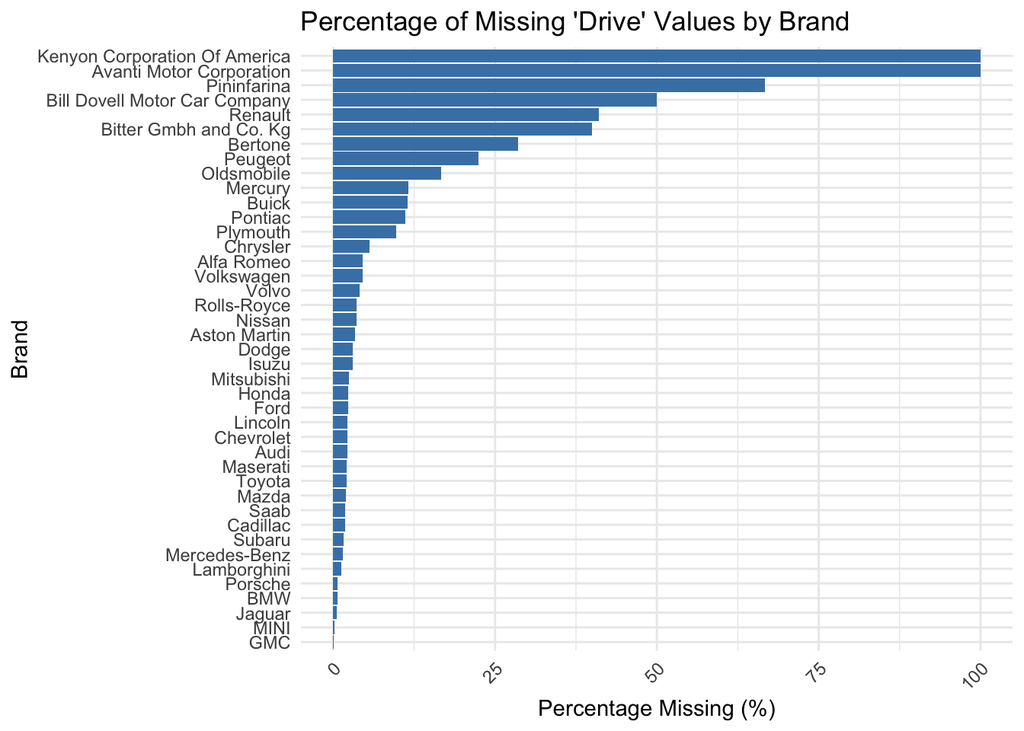

```r
# Calculate the percentage of missing 'Drive' values per brand
brand_summary <- data_cleaning %>%
  group_by(Make) %>%
  summarise(Total = n(),
            Missing = sum(is.na(Drive)),
            PercentageMissing = (Missing / Total))

# Identify brands with more than 10% missing 'Drive' data
brands_to_remove <- brand_summary %>%
  filter(PercentageMissing > brand_missing_threshold) %>%
  pull(Make)

# Filter out these brands from the dataset
data_filtered <- data_cleaning %>%
  filter(!(Make %in% brands_to_remove))

# For the remaining data, drop rows with missing 'Drive' values
data_cleaning2 <- data_filtered %>%
  filter(!is.na(Drive))
```

```r
# Create a summary dataframe of missing values by column
missing_summary_df3 <- data_cleaning2 %>%
  summarise(across(everything(), ~sum(is.na(.)))) %>%
  pivot_longer(cols = everything(), names_to = "Column", values_to = "Missing_Count") %>%
  mutate(
    Total_Rows = nrow(data),
    Proportion_Missing = Missing_Count / Total_Rows
  ) %>%
  arrange(desc(Proportion_Missing)) %>%
  select(Column, "Missing values" = Missing_Count, "Prop. Missing" = Proportion_Missing)

# Print the summary dataframe
datatable(missing_summary_df3,
          options = list(pageLength = 6,
                          class = "hover",
                          searchHighlight = TRUE),
          rownames = FALSE)%>%
  formatPercentage("Prop. Missing", 2)
```

| Column | Missing values | Prop. Missing |
| --- | --- | --- |
| Fuel.Type.2 | 40474 | 0.8818633432107373 |
| Engine.Description | 16341 | 0.3560440997036779 |
| Transmission | 8 | 0.0001743071291615827 |
| ID | 0 | 0 |
| Model.Year | 0 | 0 |
| Make | 0 | 0 |
| Model | 0 | 0 |
| Estimated.Annual.Petrolum.Consumption..Barrels. | 0 | 0 |
| Fuel.Type.1 | 0 | 0 |
| City.MPG..Fuel.Type.1. | 0 | 0 |

[output cut: 16 more lines]

```r
# Remove rows where the 'Transmission' column has missing values
data_cleaning3 <- data_cleaning2 %>%
  filter(!is.na(Transmission))
data_cleaning4 <- data_cleaning3 %>%
  mutate(Fuel.Type.2 = replace_na(Fuel.Type.2, "none"))
```

```r
# Create a summary dataframe of missing values by column
missing_summary_df3 <- data_cleaning3 %>%
  summarise(across(everything(), ~sum(is.na(.)))) %>%
  pivot_longer(cols = everything(), names_to = "Column", values_to = "Missing_Count") %>%
  mutate(
    Total_Rows = nrow(data_cleaning3),
    Proportion_Missing = Missing_Count / Total_Rows
  ) %>%
  arrange(desc(Proportion_Missing)) %>%
  select(Column, "Missing values" = Missing_Count, "Prop. Missing" = Proportion_Missing)

# Print the summary dataframe
datatable(missing_summary_df3,
          options = list(pageLength = 3,
                          class = "hover",
                          searchHighlight = TRUE),
          rownames = FALSE)%>%
  formatPercentage("Prop. Missing", 2)
```

| Column | Missing values | Prop. Missing |
| --- | --- | --- |
| Fuel.Type.2 | 40466 | 0.958001893939394 |
| Engine.Description | 16334 | 0.3866950757575758 |
| ID | 0 | 0 |
| Model.Year | 0 | 0 |
| Make | 0 | 0 |
| Model | 0 | 0 |
| Estimated.Annual.Petrolum.Consumption..Barrels. | 0 | 0 |
| Fuel.Type.1 | 0 | 0 |
| City.MPG..Fuel.Type.1. | 0 | 0 |
| Highway.MPG..Fuel.Type.1. | 0 | 0 |

[output cut: 16 more lines]

# 4 Classificatin Tree

In this section we are going to perform a classification tree analysis on the dataset. We will first load the necessary packages and the dataset. We then prepare the data by encoding categorical variables and splitting it into training and testing sets. We then tried to pruned the tree with different max_depth values to find the optimal tree depth that balances between training and test accuracy.

We first loaded the dataset and identified make as the target variable. We also encoded categorical variables using Label Encoding to convert them into numerical values.

We then splited the dataset into training (80%) and testing (20%) sets to be able to evaluate the model’s performance on unseen data after the training to check wheter the model is overfitting or not. We will see that it does.

```
max_depth   Training Accuracy   Test Accuracy
```

```
5       0.2605      0.2550
10      0.4887      0.4677
15      0.7205      0.6349
20      0.8519      0.6938
25      0.8899      0.7000
30      0.8939      0.6992
None        0.8939      0.6984
```

The model’s accuracy improved as the tree’s depth increased up to a point, with a max_depth of 25 or 30 providing the best test accuracy up to 70%. We see that reducing the max_depth to 10 or 15 improves the balance between, therefore reduce drastically the case of overfitting but this is at the expense of the accuracy of our model on new data. But we can see that pruning the tree with a max depth of 25 allows us to increase our accuracy from 69.84% to 70% therefore increasing the accuracy of our model and at the same time, it reduce the gap between the test set and the trainig set. In our case, pruning the Decision Tree helps in improving its generalization performance by preventing it from becoming too complex and reduce overfitting the training data.

# 5 Neural Network

```python
import pandas as pd
import numpy as np
from pyprojroot.here import here
import matplotlib.pyplot as plt
from sklearn.model_selection import train_test_split
from sklearn.preprocessing import StandardScaler, OneHotEncoder
from sklearn.compose import ColumnTransformer
import tensorflow as tf
from tensorflow.keras.models import Sequential
from tensorflow.keras.layers import Dense, Dropout, Input
from tensorflow.keras.utils import to_categorical

# Load the data
data = pd.read_csv(here("data/data_cleaned.csv"))

# Display the structure of the data
print(data.info())
```

```
<class 'pandas.core.frame.DataFrame'>
RangeIndex: 42240 entries, 0 to 42239
Data columns (total 18 columns):
 #   Column                        Non-Null Count  Dtype
---  ------                        --------------  -----
 0   make                          42240 non-null  object
 1   model_year                    42240 non-null  int64
 2   vehicle_class                 42240 non-null  object
 3   drive                         42240 non-null  object
 4   engine_cylinders              42237 non-null  object
 5   engine_displacement           42238 non-null  object
 6   transmission                  42240 non-null  object
 7   fuel_type_1                   42240 non-null  object
 8   city_mpg_fuel_type_1          42240 non-null  int64
 9   highway_mpg_fuel_type_1       42240 non-null  int64
 10  fuel_type_2                   42240 non-null  object
 11  city_mpg_fuel_type_2          42240 non-null  int64
 12  highway_mpg_fuel_type_2       42240 non-null  int64
 13  range_ev_city_fuel_type_1     42240 non-null  int64
 14  range_ev_highway_fuel_type_1  42240 non-null  float64
 15  range_ev_city_fuel_type_2     42240 non-null  int64
 16  range_ev_highway_fuel_type_2  42240 non-null  float64
 17  charge_time_240v              42240 non-null  float64
dtypes: float64(3), int64(7), object(8)
memory usage: 5.8+ MB
None
```

```python
# Display the first few rows of the data
print(data.head())
```

```
         make  model_year  ... range_ev_highway_fuel_type_2 charge_time_240v
0  Alfa Romeo        1985  ...                          0.0              0.0
1   Chevrolet        1985  ...                          0.0              0.0
2   Chevrolet        1985  ...                          0.0              0.0
3      Nissan        1985  ...                          0.0              0.0
4      Nissan        1985  ...                          0.0              0.0

[5 rows x 18 columns]
```

```python
# Identify categorical and numerical columns
categorical_cols = data.select_dtypes(include=['object']).columns.tolist()
numerical_cols = data.select_dtypes(include=['int64', 'float64']).columns.tolist()

# Remove the target column 'make' from the features list
if 'make' in categorical_cols:
    categorical_cols.remove('make')
if 'make' in numerical_cols:
    numerical_cols.remove('make')

print(f"Categorical columns: {categorical_cols}")
```

```
Categorical columns: ['vehicle_class', 'drive', 'engine_cylinders', 'engine_displacement', 'transmission', 'fuel_type_1', 'fuel_type_2']
```

```python
print(f"Numerical columns: {numerical_cols}")
```

```
Numerical columns: ['model_year', 'city_mpg_fuel_type_1', 'highway_mpg_fuel_type_1', 'city_mpg_fuel_type_2', 'highway_mpg_fuel_type_2', 'range_ev_city_fuel_type_1', 'range_ev_highway_fuel_type_1', 'range_ev_city_fuel_type_2', 'range_ev_highway_fuel_type_2', 'charge_time_240v']
```

```python
# Define the preprocessing steps for numerical and categorical columns
preprocessor = ColumnTransformer(
    transformers=[
        ('num', StandardScaler(), numerical_cols),
        ('cat', OneHotEncoder(sparse_output=False), categorical_cols)  # Set sparse_output to False
    ])

# Split data into features and target
X = data.drop('make', axis=1)
y = data['make']

# Apply preprocessing and split data into training and testing sets
X_preprocessed = preprocessor.fit_transform(X)

# Encode the target variable
y_encoded = pd.get_dummies(y).values

# Split the data into training and testing sets
X_train, X_test, y_train, y_test = train_test_split(X_preprocessed, y_encoded, test_size=0.2, random_state=123)

# Define the neural network model
model = Sequential([
    Input(shape=(X_train.shape[1],)),
    Dense(128, activation='relu'),
    Dropout(0.2),
    Dense(64, activation='relu'),
    Dropout(0.2),
    Dense(y_train.shape[1], activation='softmax')
])

# Compile the model
model.compile(optimizer='adam', loss='categorical_crossentropy', metrics=['accuracy'])

# Train the model
history = model.fit(X_train, y_train, epochs=10, batch_size=32, validation_split=0.2)
```

[output not shown]

[output cut: 34 more lines]

[output not shown]

```python
# Evaluate the model
loss, accuracy = model.evaluate(X_test, y_test)
```

```
  1/264 ━━━━━━━━━━━━━━━━━━━━ 1s 7ms/step - accuracy: 0.5938 - loss: 0.8014
224/264 ━━━━━━━━━━━━━━━━━━━━ 0s 225us/step - accuracy: 0.6397 - loss: 1.0023
264/264 ━━━━━━━━━━━━━━━━━━━━ 0s 226us/step - accuracy: 0.6402 - loss: 1.0017
```

```python
print(f'Test accuracy: {accuracy}')
```

```
Test accuracy: 0.6432291865348816
```

```python
# Make predictions
predictions = np.argmax(model.predict(X_test), axis=1)
```

```
  1/264 ━━━━━━━━━━━━━━━━━━━━ 3s 15ms/step
260/264 ━━━━━━━━━━━━━━━━━━━━ 0s 193us/step
264/264 ━━━━━━━━━━━━━━━━━━━━ 0s 194us/step
```

```python
# Print predictions
print(predictions)
```

```
[114  37 124 ...  36  19  19]
```

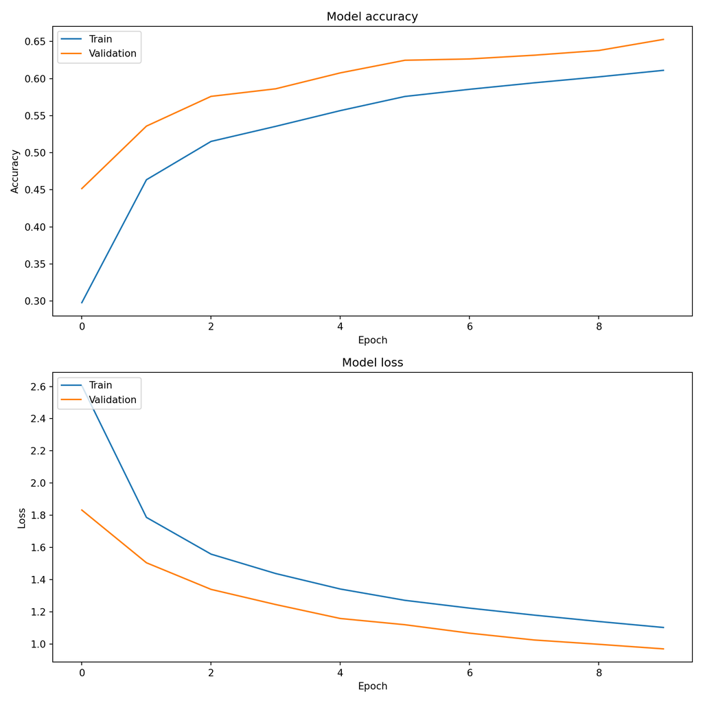

```python
# Plot the accuracy and loss
fig, axs = plt.subplots(2, 1, figsize=(10, 10))

# Plot training & validation accuracy values
axs[0].plot(history.history['accuracy'])
axs[0].plot(history.history['val_accuracy'])
axs[0].set_title('Model accuracy')
axs[0].set_ylabel('Accuracy')
axs[0].set_xlabel('Epoch')
axs[0].legend(['Train', 'Validation'], loc='upper left')

# Plot training & validation loss values
axs[1].plot(history.history['loss'])
axs[1].plot(history.history['val_loss'])
axs[1].set_title('Model loss')
axs[1].set_ylabel('Loss')
axs[1].set_xlabel('Epoch')
axs[1].legend(['Train', 'Validation'], loc='upper left')

plt.tight_layout()
plt.show()
```